# Foundations for statistical inference - Sampling distributions

```r
library(mosaic)
library(oilabs)
library(ggformula)
```

In this lab, we investigate the ways in which the statistics from a random sample of data can serve as point estimates for population parameters. We’re interested in formulating a *sampling distribution* of our estimate in order to learn about the properties of the estimate, such as its distribution.

## The data

We analyze real estate data from the city of Ames, Iowa. The details of every real estate transaction in Ames is recorded by the City Assessor’s office. Our particular focus for this lab will be all residential home sales in Ames between 2006 and 2010. This collection represents our population of interest. In this lab we would like to learn about these home sales by taking smaller samples from the full population. Let’s first load the data from the `oilabs` package and use `glimpse()` to get a preview of the data.

```r
data(ames)
glimpse(ames)
```

```
## Observations: 2,930
## Variables: 82
## $ Order           <int> 1, 2, 3, 4, 5, 6, 7, 8, 9, 10, 11, 12, 13, 14,...
## $ PID             <int> 526301100, 526350040, 526351010, 526353030, 52...
## $ area            <int> 1656, 896, 1329, 2110, 1629, 1604, 1338, 1280,...
## $ price           <int> 215000, 105000, 172000, 244000, 189900, 195500...
## $ MS.SubClass     <int> 20, 20, 20, 20, 60, 60, 120, 120, 120, 60, 60,...
## $ MS.Zoning       <fct> RL, RH, RL, RL, RL, RL, RL, RL, RL, RL, RL, RL...
## $ Lot.Frontage    <int> 141, 80, 81, 93, 74, 78, 41, 43, 39, 60, 75, N...
## $ Lot.Area        <int> 31770, 11622, 14267, 11160, 13830, 9978, 4920,...
## $ Street          <fct> Pave, Pave, Pave, Pave, Pave, Pave, Pave, Pave...
## $ Alley           <fct> NA, NA, NA, NA, NA, NA, NA, NA, NA, NA, NA, NA...
## $ Lot.Shape       <fct> IR1, Reg, IR1, Reg, IR1, IR1, Reg, IR1, IR1, R...
## $ Land.Contour    <fct> Lvl, Lvl, Lvl, Lvl, Lvl, Lvl, Lvl, HLS, Lvl, L...
## $ Utilities       <fct> AllPub, AllPub, AllPub, AllPub, AllPub, AllPub...
```

[output cut: 69 more lines]

We see that there are quite a few variables in the data set, enough to do a very in-depth analysis. For this lab, we’ll restrict our attention to just two of the variables: the above ground living area of the house in square feet (`area`) and the sale price (`price`).

We can explore the distribution of areas of homes in the population of home sales visually and with summary statistics. Let’s first create a visualization, a histogram:

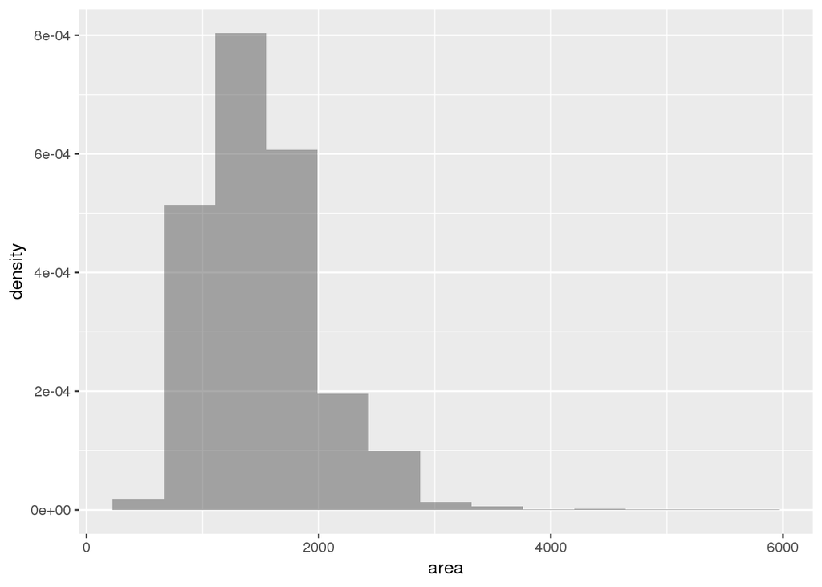

```r
gf_dhistogram(~ area, data = ames, bins = 13)
```

Let’s also generate some summary statistics. Note that we can do this using the `favstats()` function. Finding these values are useful for describing the distribution, as we can use them for descriptions like *“the middle 50% of the homes have areas between such and such square feet”*.

```r
favstats(~ area, data = ames)
```

[output not shown]

1. Describe this population distribution using the visualization and the summary statistics. You don’t have to use all of the summary statistics in your description, you will need to decide which ones are relevant based on the shape of the distribution. Make sure to include the plot and the summary statistics output in your report along with your narrative.

## The unknown sampling distribution

In this lab we have access to the entire population, but this is rarely the case in real life. Gathering information on an entire population is often extremely costly or impossible. Because of this, we often take a sample of the population and use that to understand the properties of the population.

If we were interested in estimating the mean living area in Ames based on a sample, we can use the following command to survey the population.

```r
samp1 <- ames %>%
  sample_n(50)
```

The `sample_n` function collects a simple random sample of size 50 from the `ames` dataset, which is assigned to `samp1`. This is like going into the City Assessor’s database and pulling up the files on 50 random home sales. Working with these 50 observations would be considerably simpler than working with all 2930 home sales.

1. Describe the distribution of area in this sample. How does it compare to the distribution of the population? **Hint:** the `sample_n()` function takes a random sample of observations (i.e. rows) from the dataset, you can still refer to the variables in the dataset with the same names. Code you used in the previous exercise will also be helpful for visualizing and summarizing the sample, however be careful to not label values `mu` and `sigma` anymore since these are sample statistics, not population parameters. You can customize the labels of any of the statistics to indicate that these come from the sample.

If we’re interested in estimating the average living area in homes in Ames using the sample, our best single guess is the sample mean.

```r
mean(~ area, data = samp1)
```

```
## [1] 1440.06
```

Depending on which 50 homes you selected, your estimate could be a bit above or a bit below the true population mean of 1499.69 square feet. In general, though, the sample mean turns out to be a pretty good estimate of the average living area, and we were able to get it by sampling less than 3% of the population.

1. Take a second sample, also of size 50, and call it `samp2`. How does the mean of `samp2` compare with the mean of `samp1`? Suppose we took two more samples, one of size 100 and one of size 1000. Which would you think would provide a more precise estimate of the population mean?

Not surprisingly, every time we take another random sample, we get a different sample mean. It’s useful to get a sense of just how much variability we should expect when estimating the population mean this way. The distribution of sample means, called the *sampling distribution*, can help us understand this variability. In this lab, because we have access to the population, we can build up the sampling distribution for the sample mean by repeating the above steps many times. Here we will generate 2000 samples and compute the sample mean of each. Note that since we are sampling with replacement, we use the `resample()` function instead of `sample_n()`.

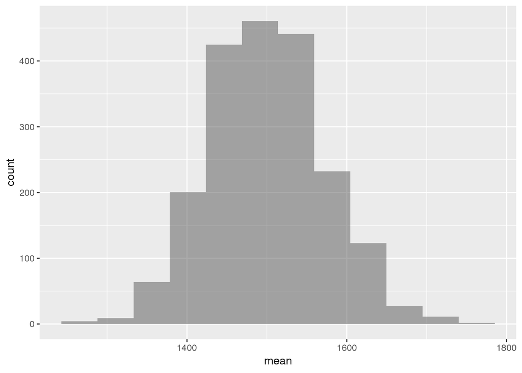

```r
sample_means50 <- do(2000) * mean(~ area, data = resample(ames, 50))
gf_histogram(~ mean, data = sample_means50, bins = 12)
```

Here we use R to take 2000 samples of size 50 from the population, calculate the mean of each sample, and store each result in a vector called `sample_means50`. On the next page, we’ll review how this set of code works.

1. How many rows are there in `sample_means50`? Describe the sampling distribution, and be sure to specifically note its center. Would you expect the distribution to change if we instead collected 10,000 sample means?

## Interlude: The `do()` function

Let’s take a break from the statistics for a moment to let that last block of code sink in. The idea behind the `do()` function is *repetition*: it allows you to execute a line of code as many times as you want and put the results in a data frame. In the case above, we wanted to repeatedly take a random sample of size 50 from `area` and then save the mean of that sample into the `sample_means50` vector.

Without the `do()` function, this would be painful. First, we’d have to create an empty vector filled with `NA`s to hold the 2000 sample means. Then, we’d have to use a `for` loop to compute each of the 2000 sample means one line at a time, putting them individually into the slots of the `sample_means50` vector:

```r
sample_means50 <- rep(NA, 2000) #create empty vector

sample_means50[1] <- mean(~ area, data = resample(ames, 50))
sample_means50[2] <- mean(~ area, data = resample(ames, 50))
sample_means50[3] <- mean(~ area, data = resample(ames, 50))
sample_means50[4] <- mean(~ area, data = resample(ames, 50))
# ...and so on, 2000 times
```

With the `do` function, these lines of code are expressed into one line:

```r
sample_means50 <- do(2000) * mean(~ area, data = resample(ames, 50))
```

Note that for each of the 2,000 times we computed a mean, we did so from a **different** random sample!

1. To make sure you understand what the `resample()` and `do()` functions do, try modifying the code to take only **25 sample means** from **samples of size 10**, and save them in a data frame named `sample_means_small`. Print the output. How many elements are there in this object called `sample_means_small`? What does each element represent?